# DATA608 - Assignment 1

Mael Illien

9/5/2020

**Principles of Data Visualization and Introduction to ggplot2**

```r
library(tidyverse)
```

##### I have provided you with data about the 5,000 fastest growing companies in the US, as compiled by Inc. magazine. lets read this in:

```r
inc <- read.csv("https://raw.githubusercontent.com/charleyferrari/CUNY_DATA_608/master/module1/Data/inc5000_data.csv", header= TRUE)
```

And lets preview this data:

```r
head(inc)
```

|  | Rank | Name | Growth_Rate | Revenue | Industry | Employees | City | State |
| --- | --- | --- | --- | --- | --- | --- | --- | --- |
| 1 | 1 | Fuhu | 421.48 | 1.179e+08 | Consumer Products & Services | 104 | El Segundo | CA |
| 2 | 2 | FederalConference.com | 248.31 | 4.960e+07 | Government Services | 51 | Dumfries | VA |
| 3 | 3 | The HCI Group | 245.45 | 2.550e+07 | Health | 132 | Jacksonville | FL |
| 4 | 4 | Bridger | 233.08 | 1.900e+09 | Energy | 50 | Addison | TX |
| 5 | 5 | DataXu | 213.37 | 8.700e+07 | Advertising & Marketing | 220 | Boston | MA |
| 6 | 6 | MileStone Community Builders | 179.38 | 4.570e+07 | Real Estate | 63 | Austin | TX |

```r
summary(inc)
```

```
      Rank                          Name       Growth_Rate         Revenue
 Min.   :   1   (Add)ventures         :   1   Min.   :  0.340   Min.   :2.000e+06
 1st Qu.:1252   @Properties           :   1   1st Qu.:  0.770   1st Qu.:5.100e+06
 Median :2502   1-Stop Translation USA:   1   Median :  1.420   Median :1.090e+07
 Mean   :2502   110 Consulting        :   1   Mean   :  4.612   Mean   :4.822e+07
 3rd Qu.:3751   11thStreetCoffee.com  :   1   3rd Qu.:  3.290   3rd Qu.:2.860e+07
 Max.   :5000   123 Exteriors         :   1   Max.   :421.480   Max.   :1.010e+10
                (Other)               :4995
                         Industry      Employees                  City          State
 IT Services                 : 733   Min.   :    1.0   New York     : 160   CA     : 701
 Business Products & Services: 482   1st Qu.:   25.0   Chicago      :  90   TX     : 387
 Advertising & Marketing     : 471   Median :   53.0   Austin       :  88   NY     : 311
 Health                      : 355   Mean   :  232.7   Houston      :  76   VA     : 283
 Software                    : 342   3rd Qu.:  132.0   San Francisco:  75   FL     : 282
 Financial Services          : 260   Max.   :66803.0   Atlanta      :  74   IL     : 273
 (Other)                     :2358   NA's   :12        (Other)      :4438   (Other):2764
```

##### Think a bit on what these summaries mean. Use the space below to add some more relevant non-visual exploratory information you think helps you understand this data:

The summaries below help to understand the skew of the data the via the total, average and mean columns and also provide an aggregate of the revnue per state and per industry.

| State | CompanyCount | TotEmployee | AvgEmployee | StdEmployee | SumRevenue_b |
| --- | --- | --- | --- | --- | --- |
| CA | 701 | 161219 | 229.98 | 1212.83 | 23.4579 |
| TX | 387 | 90765 | 234.53 | 738.57 | 22.1642 |
| NY | 311 | 84370 | 271.29 | 1916.18 | 18.2604 |
| VA | 283 | 35667 | 126.03 | 263.66 | 8.6677 |
| FL | 282 | 61221 | 217.10 | 960.70 | 10.6103 |
| IL | 273 | 103266 | 378.26 | 1461.10 | 33.2443 |
| OH | 186 | 38002 | 204.31 | 818.26 | 12.7866 |
| NC | 137 | 36685 | 267.77 | 813.98 | 9.2585 |
| MI | 126 | 36905 | 292.90 | 850.47 | 7.8058 |
| WI | 79 | 15548 | 196.81 | 748.44 | 7.2966 |

| Industry | CompanyCount | TotEmployee | AvgEmployee | StdEmployee | SumRevenue_b |
| --- | --- | --- | --- | --- | --- |
| IT Services | 733 | 102788 | 140.23 | 392.14 | 20.6813 |
| Business Products & Services | 482 | 117357 | 243.48 | 1516.44 | 26.3679 |
| Advertising & Marketing | 471 | 39731 | 84.35 | 287.40 | 7.7850 |
| Health | 355 | 82430 | 232.20 | 490.42 | 17.8634 |
| Software | 342 | 51262 | 149.89 | 267.30 | 8.1406 |
| Financial Services | 260 | 47693 | 183.43 | 302.83 | 13.1509 |
| Manufacturing | 256 | 43942 | 171.65 | 615.98 | 12.6840 |
| Consumer Products & Services | 203 | 45464 | 223.96 | 1214.94 | 14.9564 |
| Retail | 203 | 37068 | 182.60 | 594.90 | 10.2574 |
| Government Services | 202 | 26185 | 129.63 | 182.64 | 6.0091 |
| Human Resources | 196 | 226980 | 1158.06 | 5474.04 | 9.2461 |
| Construction | 187 | 29099 | 155.61 | 589.23 | 13.1743 |
| Logistics & Transportation | 155 | 39994 | 258.03 | 926.04 | 14.8405 |
| Food & Beverage | 131 | 65911 | 503.14 | 1242.12 | 12.9113 |
| Telecommunications | 129 | 30842 | 239.09 | 913.23 | 7.3344 |
| Energy | 109 | 26437 | 242.54 | 454.36 | 13.7716 |
| Real Estate | 96 | 18893 | 196.80 | 410.90 | 2.9657 |
| Education | 83 | 7685 | 92.59 | 136.42 | 1.1393 |
| Engineering | 74 | 20435 | 276.15 | 1166.04 | 2.5325 |
| Security | 73 | 41059 | 562.45 | 2433.98 | 3.8128 |
| Travel & Hospitality | 62 | 23035 | 371.53 | 900.79 | 2.9316 |
| Media | 54 | 9532 | 176.52 | 502.23 | 1.7424 |
| Environmental Services | 51 | 10155 | 199.12 | 742.18 | 2.6388 |
| Insurance | 50 | 7339 | 146.78 | 412.92 | 2.3379 |
| Computer Hardware | 44 | 9714 | 220.77 | 1016.74 | 11.8857 |

## Question 1

##### Create a graph that shows the distribution of companies in the dataset by State (ie how many are in each state). There are a lot of States, so consider which axis you should use. This visualization is ultimately going to be consumed on a ‘portrait’ oriented screen (ie taller than wide), which should further guide your layout choices.

I chose to use a sorted bar graph. The large number of states justifies the flip in axes. The bar graph uses length to display information which is is visually easy to interpret, while the sorting eliminates having to visually compare non-adjacent bars.

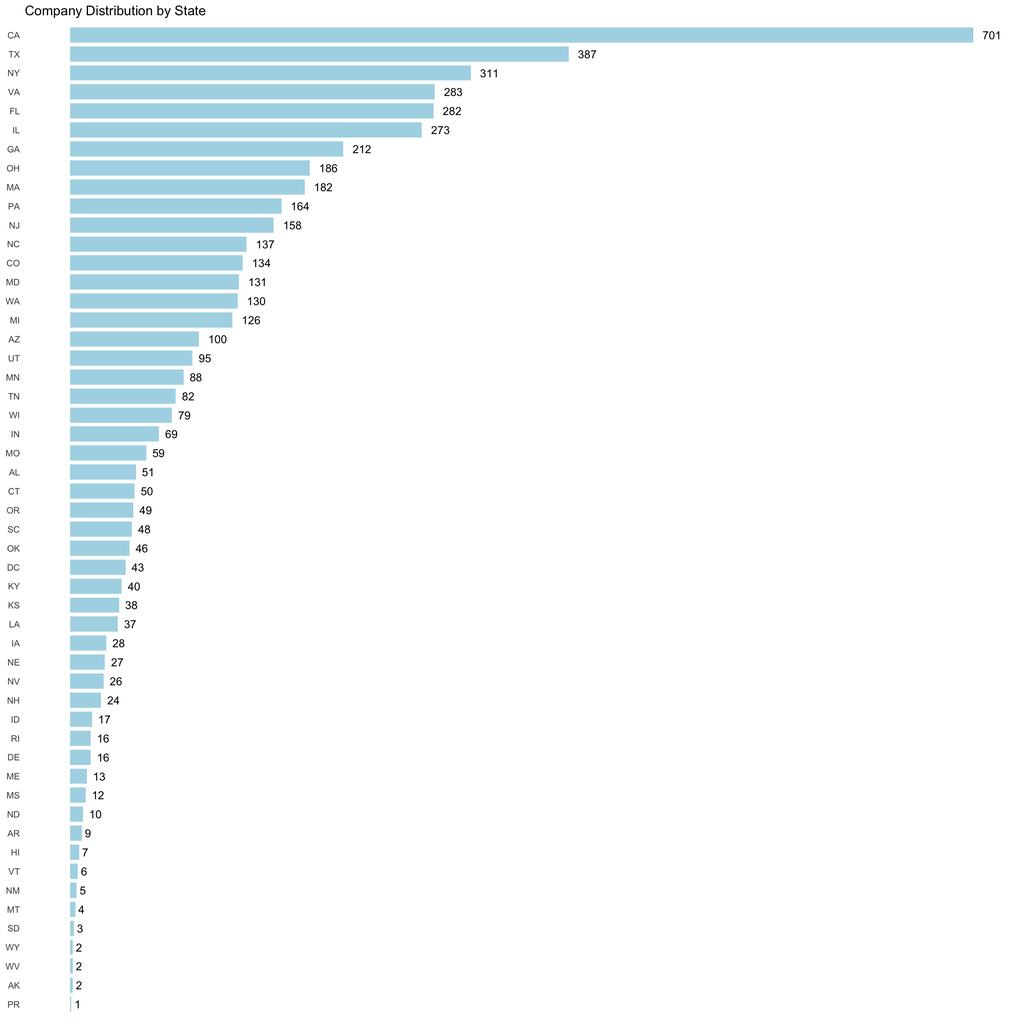

## Question 2

##### Lets dig in on the state with the 3rd most companies in the data set. Imagine you work for the state and are interested in how many people are employed by companies in different industries. Create a plot that shows the average and/or median employment by industry for companies in this state (only use cases with full data, use R’s `complete.cases()` function.) In addition to this, your graph should show how variable the ranges are, and you should deal with outliers.

I chose the boxplot and the log transform because the it had the nicest spread of data over the plot and allowed for the larger industries not to visually swamp out the smaller ones. Sorting the boxplot by median also helps to makes the pattern in the mean more discernable. While the data may have a nice spread, the reader may have difficulties interpreting the mean and median values relative to the log scale.

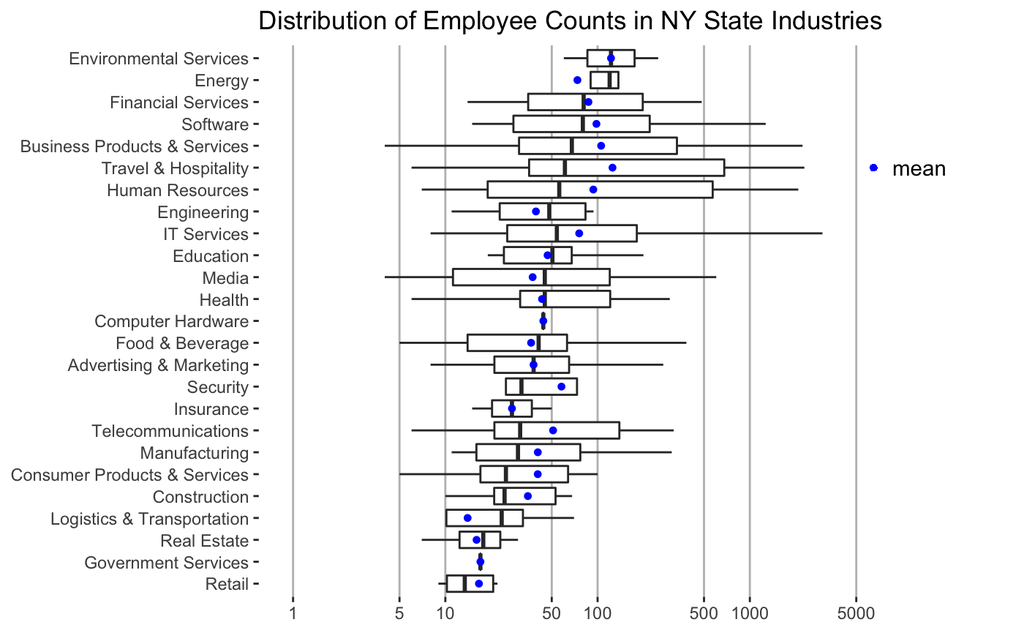

## Question 3

##### Now imagine you work for an investor and want to see which industries generate the most revenue per employee. Create a chart that makes this information clear. Once again, the distribution per industry should be shown.

Here, a rotated and sorted bar seemed again to be the most appropriate choice. The bar labels were divided by 10^3 and rounded to make the number more digestible to the user.

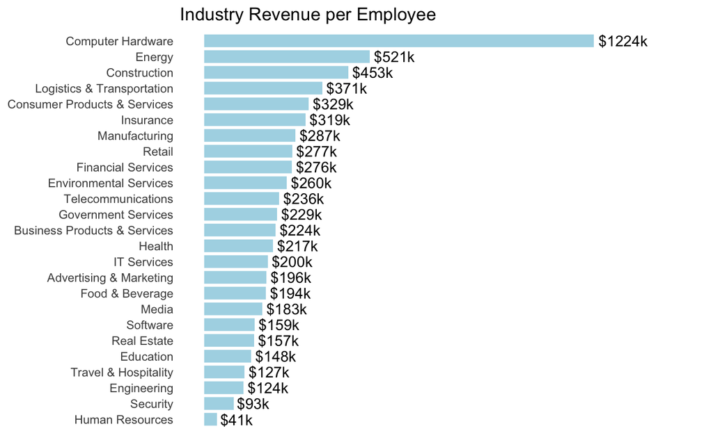